# Memory Loss and Marijuana Use

## Two sample t-test of difference of means

As part of a research project on the effects that marijuana smoking has on short-term memory, two groups of ten subjects were tested. One group, the “nonsmokers”, claimed not to smoke marijuana. A second group, the “smokers,” claimed to smoke marijuana regularly. The following are the number items remembered successfully on the digit span task.

```r
nonsmokers <- c(18, 22, 21, 17, 20, 17, 23, 20, 22, 21)
smokers <- c(16, 20, 14, 21, 20, 18, 13, 15, 17, 21)
n1 <- length(nonsmokers)
n2 <- length(smokers)
mean(nonsmokers)
```

```
[1] 20.1
```

```r
mean(smokers)
```

```
[1] 17.5
```

Two-sample t-test: $H_0: \mu_1 = \mu_2$ Assumptions: 1. Independent observations from both populations 2. Observations from both groups are drawn from normally distributed populations 3. The two populations have the same variance (if not using Welch’s test)

```r
tt <- t.test(nonsmokers, smokers, var.equal = TRUE)
tt
```

```
    Two Sample t-test

data:  nonsmokers and smokers
t = 2.2573, df = 18, p-value = 0.03665
alternative hypothesis: true difference in means is not equal to 0
95 percent confidence interval:
 0.1801366 5.0198634
sample estimates:
mean of x mean of y
     20.1      17.5
```

Welch’s t-test

```r
ttw <- t.test(nonsmokers, smokers, var.equal = FALSE)
ttw
```

```
    Welch Two Sample t-test

data:  nonsmokers and smokers
t = 2.2573, df = 16.376, p-value = 0.03798
alternative hypothesis: true difference in means is not equal to 0
95 percent confidence interval:
 0.1628205 5.0371795
sample estimates:
mean of x mean of y
     20.1      17.5
```

Assumptions from bootstrap procedure 1. Independent observations from both populations

```r
observed_difference <- mean(nonsmokers) - mean(smokers)
observed_difference
```

```
[1] 2.6
```

Note that what we’re interested in here is the value of this `observed_difference` as a way of testing a difference in means. Now, we can use bootstrap sampling of both samples to build a distribution around the difference in means.

```r
n_samples <- 10000
sample_differences <- replicate(n_samples, mean(sample(nonsmokers, replace = TRUE)) - mean(sample(smokers, replace = TRUE)))
```

Let’s investigate the distribution of `sample_differences`.

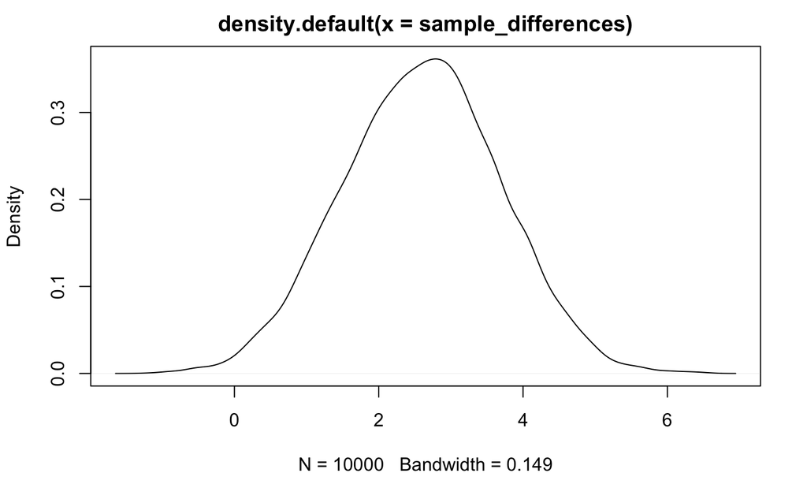

```r
plot(density(sample_differences))
```

Using this distribution, we can build a confidence interval around the difference in sample means.

```r
ci <- quantile(sample_differences, probs = c(0.025, 0.975))
ci
```

```
 2.5% 97.5%
  0.5   4.7
```

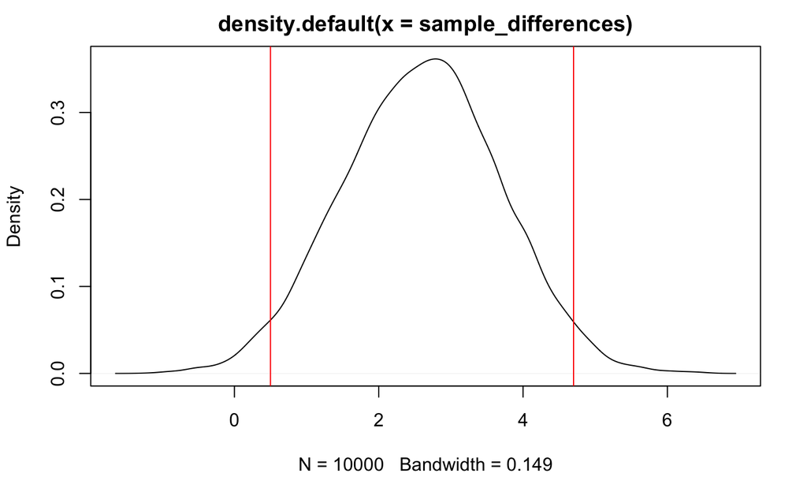

```r
plot(density(sample_differences))
abline(v = ci, col = "red")
```

Using this method, we come to the same conclusion that we did using the t-test, namely that we can reject the null hypothesis.